# Lab 5

## Lab 5

### Due Tuesday Feb1st - Recommended to complete this before starting the midterm

This lab we will look at some data from the plastic trash piced up during clean-up events around the world. I took this dataset from the Tidy Tuesday website. You can read the documentation [here](https://github.com/rfordatascience/tidytuesday/blob/master/data/2021/2021-01-26/readme.md), including the references and description of the different column names.

I have done some pre-processing of the data for you for this lab, to create two more easy-to-use dataframes.

First read in the countrytotals.csv data frame

```r
setwd('C:/Users/judy8/Box/PhD_UCD/UCD_course/Winter_2023/ESP106/Lab/Lab5/Data')
countrytotals <- read.csv('countrytotals.csv')
continenttypes <- read.csv("continenttypes.csv")

str(countrytotals)
```

```
## 'data.frame':    55 obs. of  13 variables:
##  $ X         : int  1 2 3 4 5 6 7 8 9 10 ...
##  $ country   : chr  "Argentina" "Armenia" "Australia" "Bangladesh" ...
##  $ empty     : int  128 0 4 0 0 0 8 0 0 0 ...
##  $ hdpe      : int  132 0 33 376 0 114 11 267 117 211 ...
##  $ ldpe      : int  141 0 222 2 0 572 34 20 611 226 ...
##  $ o         : int  212 0 898 1559 0 376 125 3623 440 700 ...
##  $ pet       : int  144 8 141 299 342 417 74 4664 283 456 ...
##  $ pp        : int  263 0 361 89 0 548 199 68 277 383 ...
##  $ ps        : int  62 0 3 58 0 208 15 90 159 43 ...
##  $ pvc       : int  4 0 6 0 0 22 14 42 0 14 ...
##  $ total     : int  1086 8 1668 2383 342 2257 480 8774 1887 2033 ...
##  $ num_events: int  5424 4 621 142 4 88 105 15 129 363 ...
##  $ volunteers: int  2034 12 13110 18034 916 1716 750 2445 559 1573 ...
```

```r
str(continenttypes)
```

```
## 'data.frame':    48 obs. of  5 variables:
##  $ X           : int  1 2 3 4 5 6 7 8 9 10 ...
##  $ continent   : chr  "Africa" "Africa" "Africa" "Africa" ...
##  $ plastic_type: chr  "empty" "hdpe" "ldpe" "o" ...
##  $ total       : int  335 8718 16460 26764 54696 3292 2158 73 693 2969 ...
##  $ events      : int  6559 6559 6559 6559 6559 6559 6559 6559 45174 45174 ...
```

Have a look at the data frame. Then column “total” gives the total number of pieces of plastic picked up in that country in 2020. The columns “num_events” and “volunteers” give the number of trash pick-up events and the number of volunteers in that country. We are going to use this to investigate where the plastic trash problem is worst.

# Q1. What 5 countries had the worst plastic problem as measured by the number of pieces of trash picked up?

```
## 'data.frame':    55 obs. of  13 variables:
##  $ X         : int  35 37 46 21 49 22 26 55 18 8 ...
##  $ country   : chr  "Nigeria" "Philippines" "Switzerland" "India" ...
##  $ empty     : int  316 344 2342 22 0 7 0 112 0 0 ...
##  $ hdpe      : int  7532 82 102 489 0 1304 340 212 220 267 ...
##  $ ldpe      : int  15470 3939 1528 6684 0 1461 61 198 291 20 ...
##  $ o         : int  8284 4272 45612 7369 11233 1473 294 4779 0 3623 ...
##  $ pet       : int  27390 2949 1018 895 759 2818 7797 1516 8272 4664 ...
##  $ pp        : int  2234 41987 902 1107 0 2912 364 394 0 68 ...
##  $ ps        : int  2011 600 722 67 2 145 0 1587 0 90 ...
##  $ pvc       : int  16 1011 51 340 0 36 0 11 0 42 ...
##  $ total     : int  63253 55184 52277 16973 11994 10156 8856 8809 8783 8774 ...
##  $ num_events: int  6030 2040 1746 19488 5 14700 114 768 52 15 ...
##  $ volunteers: int  703165 109800 52380 122844 460 115248 23104 3456 8060 2445 ...
```

```
##  [1] 63253 55184 52277 16973 11994 10156  8856  8809  8783  8774
```

**Answer:**

#Q2. Make a plot showing the distribution of volunteers across countries

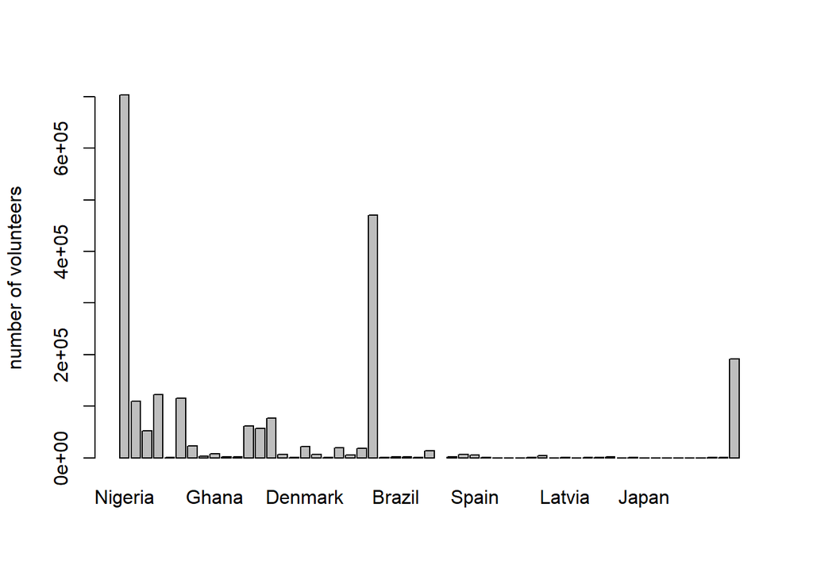

```r
barplot(sort_countrytotals$volunteers, names.arg = sort_countrytotals$country,
        ylab = 'number of volunteers')
```

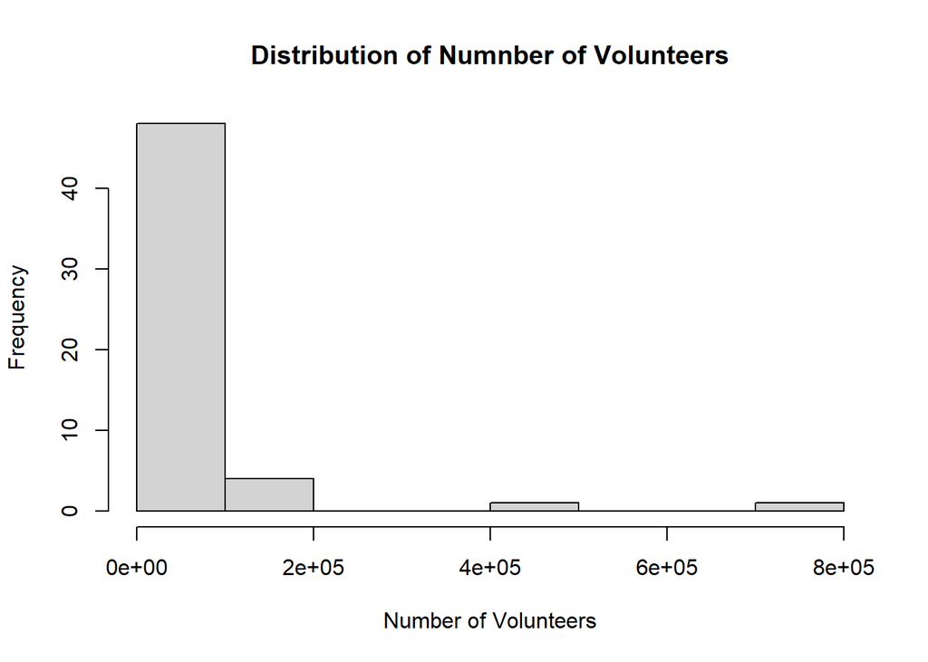

```r
hist(countrytotals$volunteers,xlab="Number of Volunteers",ylab="Frequency",main="Distribution of Numnber of Volunteers")
```

#Q3. Notice that there is a lot of variation across countries in the number of volunteers involved in trash pickup. What problem might that cause for the interpretation of your answer to question 1?

**Answer:**

#Q4. Add a column to the data frame creating a variable that should be more closely related to the presence of plastic pollution in the country

#Q5. What 5 countries have the worst plastic pollution, as measured by this new variable?

```
## [1] "Togo"        "El Salvador" "Japan"       "Kuwait"      "Germany"
```

**Answer:**

Now we will make a plot of the variation in the types of trash and how it differs around the world. Read in the continenttypes.csv data frame. This gives the breakdown of the different types of plastic collected on each continet in 2020 and the total number of pick up events.

#Q6. Add a column to this data frame with a variable that captures the existence of different types of plastic trash, controlling for the intensity of the pick-up effort in different continent

#Q7. Make a plot using ggplot showing both the total amount and distribution of types of plastic picked up in each continent in the average pick-up event.

Hint: Check out options in the [R graph gallery](https://www.r-graph-gallery.com)

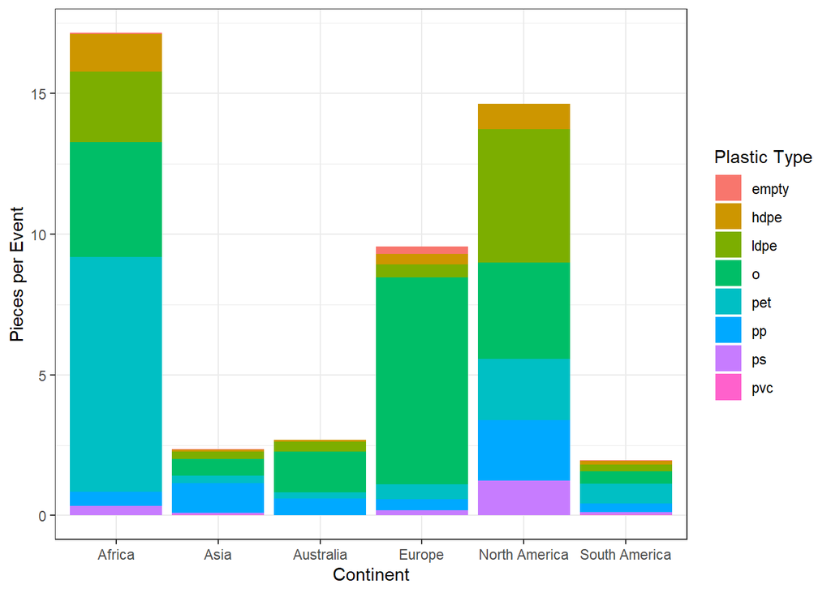

#Q8. Try uploading your R markdown file and plot to your Git Hub repository. Don’t put your knitted HTML file in Github - these are large files that are not designed to be stored on Github